# Árvore de decisão - Titanic

### Análise bivariada

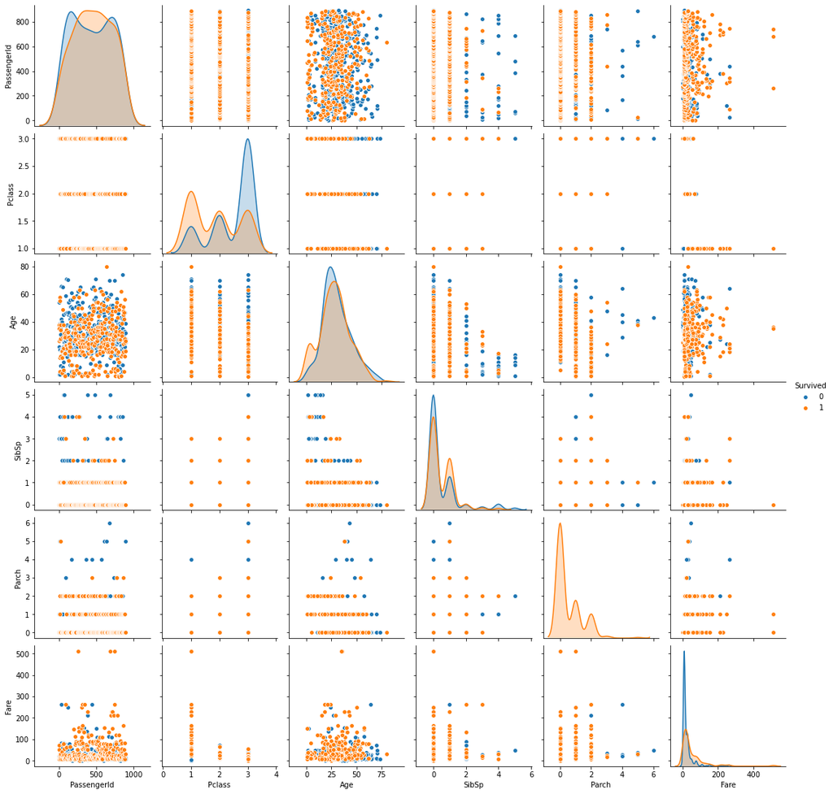

```python
import seaborn as sns
sns.pairplot(df, hue='Survived')
```

Pelos gráficos acima expostos, pode-se observar que nenhuma das variáveis apresenta relação linear, o que indica que um modelo linear não seria eficaz para modelar esse tipo de dados e que um modelo de classificação (como o que será proposto) é mais adequado.

## Reestruturando a base de dados

As variáveis *Sex* e *Embarked* são categóricas. Ambas serão transformadas em *dummies* para serem introduzidas de forma adequada na árvore de decisão.

```python
df = pd.get_dummies(df, columns=['Sex', 'Embarked'])
df.head()
```

|  | PassengerId | Survived | Pclass | Name | Age | SibSp | Parch | Ticket | Fare | Cabin | Sex_female | Sex_male | Embarked_C | Embarked_Q | Embarked_S |
| --- | --- | --- | --- | --- | --- | --- | --- | --- | --- | --- | --- | --- | --- | --- | --- |
| 0 | 1 | 0 | 3 | Braund, Mr. Owen Harris | 22.0 | 1 | 0 | A/5 21171 | 7.2500 | NaN | 0 | 1 | 0 | 0 | 1 |
| 1 | 2 | 1 | 1 | Cumings, Mrs. John Bradley (Florence Briggs Th... | 38.0 | 1 | 0 | PC 17599 | 71.2833 | C85 | 1 | 0 | 1 | 0 | 0 |
| 2 | 3 | 1 | 3 | Heikkinen, Miss. Laina | 26.0 | 0 | 0 | STON/O2. 3101282 | 7.9250 | NaN | 1 | 0 | 0 | 0 | 1 |
| 3 | 4 | 1 | 1 | Futrelle, Mrs. Jacques Heath (Lily May Peel) | 35.0 | 1 | 0 | 113803 | 53.1000 | C123 | 1 | 0 | 0 | 0 | 1 |
| 4 | 5 | 0 | 3 | Allen, Mr. William Henry | 35.0 | 0 | 0 | 373450 | 8.0500 | NaN | 0 | 1 | 0 | 0 | 1 |

A base será separada em outras duas bases, X e Y, onde:

- *X*: Base contendo as variáveis explicativas. Serão retiradas as variáveis *PassengerID*, *Name*, *Ticket* e *Cabin* por serem variáveis com valores muito relacionados a passageiros específicos, e mantê-las no modelo poderia causar *overfitting*. Também será retirada a variável *Survived*, pois ela representa o fenômeno o qual há interesse em explicar.
- *Y*: Base contendo apenas a variável *Survived*.

```python
X = df.drop(['Survived', 'PassengerId', 'Name', 'Ticket', 'Cabin'], axis=1)
y = df['Survived']
```

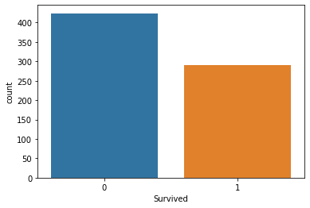

```python
sns.countplot(y)
```